# Wizualizacja danych - dobre praktyki - raport

Helena Wałachowska

2023-03-20

## Wstęp

Techniki wizualizacji danych, czyli jak w czytelny i przystępny dla odbiorcy sposób przedstawiać informacje na wykresach? W niniejszej pracy zaprezentuję rezultaty wykonanego przez mnie eksperymentu, którego celem było zbadanie, czy powszechnie polecane i stosowane dobre praktyki tworzenia wizualizacji danych rzeczywiścia się sprawdzają. Praca została wykonana w oparciu o dane dotyczące finalistów Olimpiady Matematycznej zaczerpnięte ze strony: [smarterpoland.pl](http://smarterpoland.pl/index.php/zbiory-danych/)

## Opis eksperymentu

W ramach eksperymentu wykonałam dwa wykresy kołowy i słupkowy przedstawiające liczbę finalistów pierwszych 59 edycji OM pochodzących z poszczególnych województw. Starałam się, aby oba wykresy były czytelne i przedstawiały wszyskie istotne informacje. Chciałam sprawdzić, który wykres okaże się bardziej przystępny i użyteczny dla odbiorcy. W tym celu przeprowadziłam ankietę wśród 18 osób.

Na wykresie kołowym postanowiłam nie dodawać etykiet opisujących najmniejsze wartości, aby nie zaburzać dodatkowo czytelności wykresu.

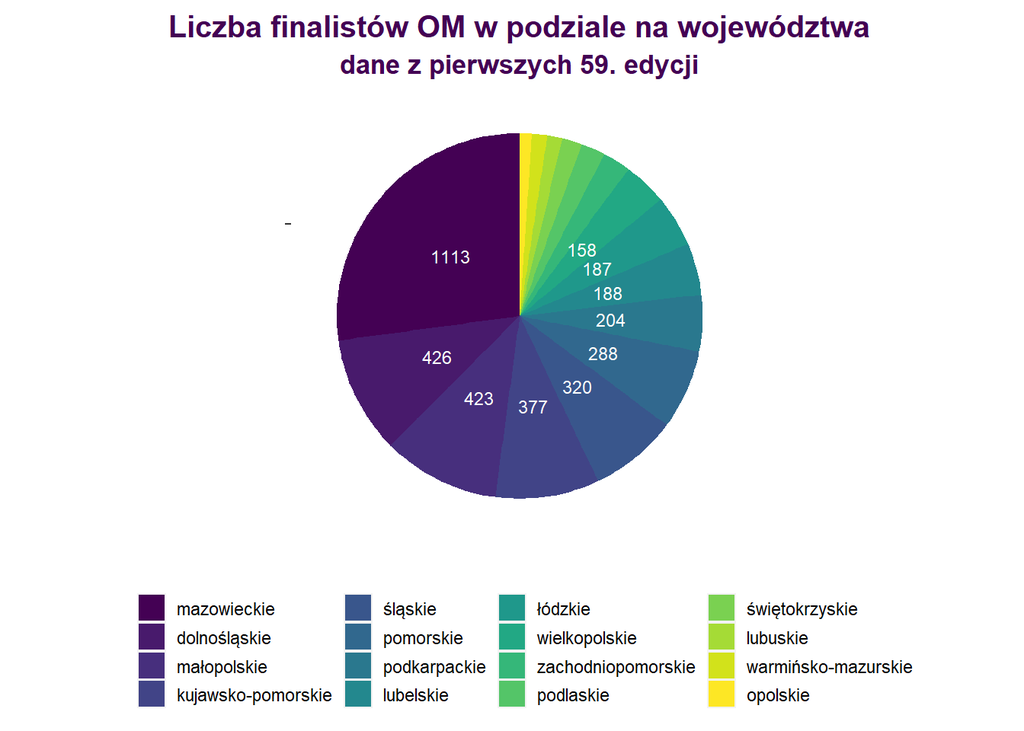

Przypuszczałam, że wykres słupkowy powinien okazać się łatwiejszy w odbiorze ze względu na możliwość bezpośredniego podpisania osi oraz bardziej widoczne różnice w długości słupków nawet pomiędzy bardzo zbliżonymi obserwacjami.

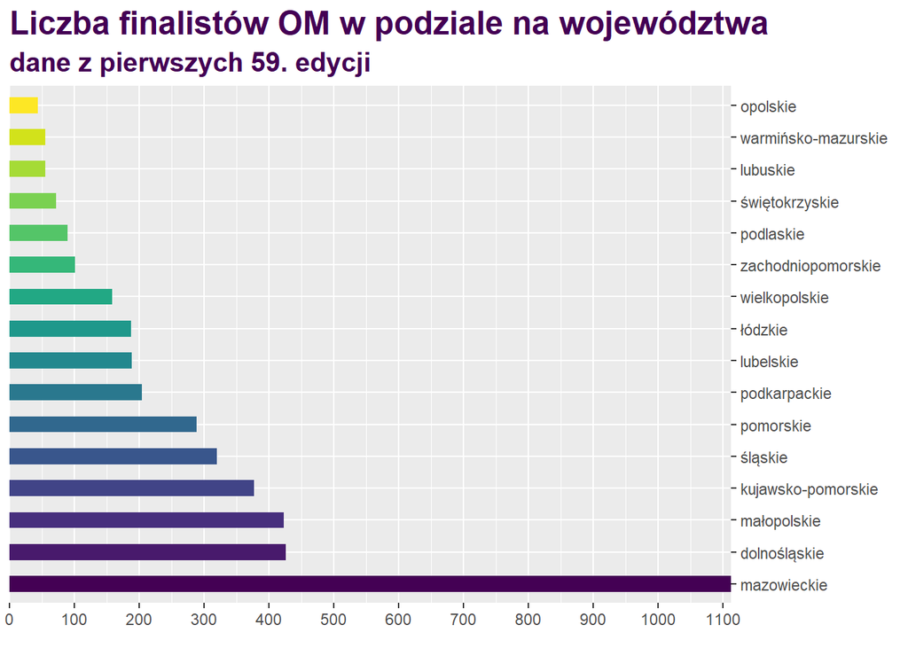

W celu weryfikacji mojej hipotezy zadałam ankietowanym osobom trzy pytania (analogiczne dla wykresu kołowego i słupkowego), aby sprawdzić, z którego wykresu więcej osób odczyta oczekiwane informacje poprawnie. Pytania były następujące:

1. Które województwo może pochwalić się większą liczbą finalistów OM opolskie czy warmińsko-mazurskie, a może oba osiągnęły ten sam wynik?
2. Z którego województwa pochodziło 158 finalistów?
3. Ilu finalistów pochodziło z woj. podlaskiego?

Na koniec ankiety zadałam pytanie “Z którym z dwóch przedstawionych wykresów było Ci łatwiej pracować?”.

## Wyniki

Po zebraniu i zliczeniu poprawnych odpowiedzi ankietownaych okazało się, że postawiona hipoteza okazała się poprawna, ponieważ na każde z trzech pytań więcej odpowiedzi poprawnych uzyskano dzięki wykresowi słupkowemu.

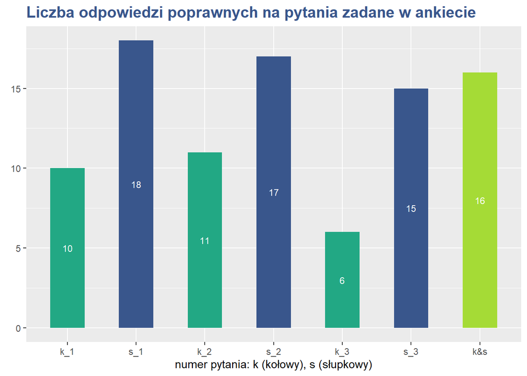

- W przypadku pierwszego pytania była to różnica 8 głosów. Pytanie to sprawdzało czy ankietowani będą w stanie odróżnić od siebie bardzo zbliżone informacje nieopatrzone etykietami. Co istotne dzięki wykresowi słupkowemu udało się w tym przypadku osiągnąć 100% poprawność odpowiedzi.
- Drugie pytanie osiągnęło bardzo podobny wynik, ponieważ poprawność odpowiedzi dla wykresu słupkowego wyniosła 17, a dla kołowego 11. Pytanie to miało wykazać jak szybko i trafnie odbiorcy są w stanie zlokalizować oczekiwany punkt na wykresie korzystjąc z opisów osi oraz kolorów. Słaby wynik dla wykresu kołowego mógł być spowodowany zbliżoną kolorystyką obserwacji na wykresie i koniecznością połączenia ich z legendą, co zwykle powodowało wybieranie sąsiadujących z woj. wielkoposkim (poprawna odpowiedź) możliwości.
- Trzecie pytanie wypadło najgorzej na tle pozostałych w przypadku obu wykresów. Uzyskałam 15 poprawnych odpowiedzi dla wykresu słupkowego i 6 dla wykresu kołowego (za poprawną odpowiedź uznawałam wszystkie różniżące się max o 11 od właściwej wartości 89). Pytanie to sprawdzało na ile trafnie ankietowani są w stanie określić liczbę finalistów dla wybranego województwa porównując długość słupka czy wielkość wycinka do tych dokładnie opisanych. Takie szacowanie okazało się 2,5 raza bardziej skuteczne przy użyciu wykresu słupkowego.
- W ostatnim pytaniu 16/18 osób wybrało wykres słupkowy jako bardziej czytelny i wygodny w użyciu w przypadku rozwiązywanej ankiety.

## Podsumowanie

Jak pokazał przeprowadzony eksperyment, warto stosować w praktyce sprawdzone zasady dotyczące tworzenia wykresów i wizualizacji danych. Zwiększa to jasność przekazu i szybkość odbioru, a także zmieniejsza ryzyko nieporozumień i niezamierzonych przekłamań na wykresach.